# Towards Spatial Data Science

Jul 12, 2019, Spatial Statistics Conference; https://edzer.github.io/spasta/

## Overview

- data science, open data science
- the Earth is round
- big data, interoperability, and luxury problems?

## What is data Science?

Combining

- statististical understanding
- data manipulation / software engineering skills
- domain knowledge (understanding data)

into a single person. And then, what they do.

## Bryan & Wickham, 2017

- *Data Science has at least one advantage over Statistics, which partially explains its existence. Re-defining an existing field like Statistics is terribly difficult, whereas it’s much easier to define something new from scratch.*
- *We see a substantial mismatch between what is needed to learn from data and the much smaller subset of activity that is structurally rewarded in academic statistics today.*

From: Jennifer Bryan, and Hadley Wickham, 2017. Data Science: A Three Ring Circus or a Big Tent? Journal of Computational and Graphical Statistics 26 (4) (part of a collection of discussion pieces on David Donoho’s paper "50 Years of Data Science".)

[figure not shown]

## Why do we have data science?

- "data is the new oil"; data is an economic resource for:
  - profiling
  - what will be my next purchase
  - which movie will I play next
  - Big IT, many Smaller IT, Government (security/intelligence, also public/open purposes: energy, traffic)
- data science is an enabler for open (data) science
  - this interests me

## Open (data) science

- this should be a tautology, but isn't, and needs to be brought up until it is
- science vs. engineering
- reproducibility:
  - share data, to the extent possible
  - share software and/or scripts
  - uses open source software ("the science of where")
  - open access to all material, including publications
  - follow FAIR principles: findable, accessible, interoperable and reusable
- In principle, we can do this, in practice, we don't

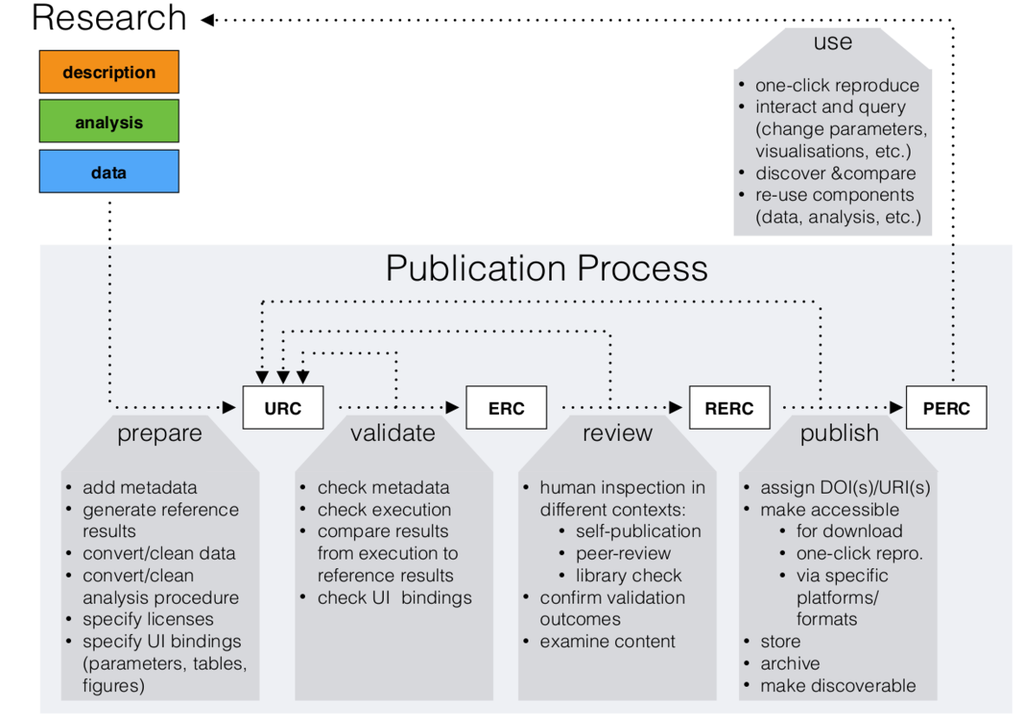

## Open Data Science is a mindset

(Julia Stewart Lowndes, "R for better science in less time", UseR!2019, Jul 10)

- rather than exchange finished products (papers), learn to share work at an early stage
- (an idea embraced earlier in open source software development)
- "Harness the power of welcome" (create safe, diverse, and inclusive spaces)
- different social interaction: code of conducts,
- focus on diversity (RLadies, scholarships), recent datacamp pushback,
- Build community: organize hackatons, unconferences, meetups, developer days:
- Communicate by: github issues, slack, hex stickers, twitter
- (How) do we foster an open science mindset?

## How we do science; thought experiment 1:

You are going to meet for three days with 100 (other) experts to solve problems you have in common. Who of you would propose to use this time to split the complete time in 15+2 minutes oral presentations?

## How we do science; thought experiment 2:

Besides conferences, we also communicate research findings by publishing research papers. How many comments or questions do you receive about the *contents* of a published paper, on average?

## What then is Spatial (open) Data Science?

Waldo Tobler's First Law of Geography? ("Everything is related to everything else, but near things are more related than distant things"). Check. Fisher knew.

## The Earth is round

and most spatial data, Today, come with geographical (long/lat) coordinates, usually related to WGS84.

- however:

```r
library(sf)
(line = st_linestring(rbind(c(0,10), c(10,10))))
```

```
## LINESTRING (0 10, 10 10)
```

```r
(point = st_point(c(5, 10)))
```

```
## POINT (5 10)
```

```r
st_intersection(st_sfc(line, crs = 4326), st_sfc(point, crs = 4326))[[1]]
```

```
## although coordinates are longitude/latitude, st_intersection assumes that they are planar
```

```
## POINT (5 10)
```

## More seriously:

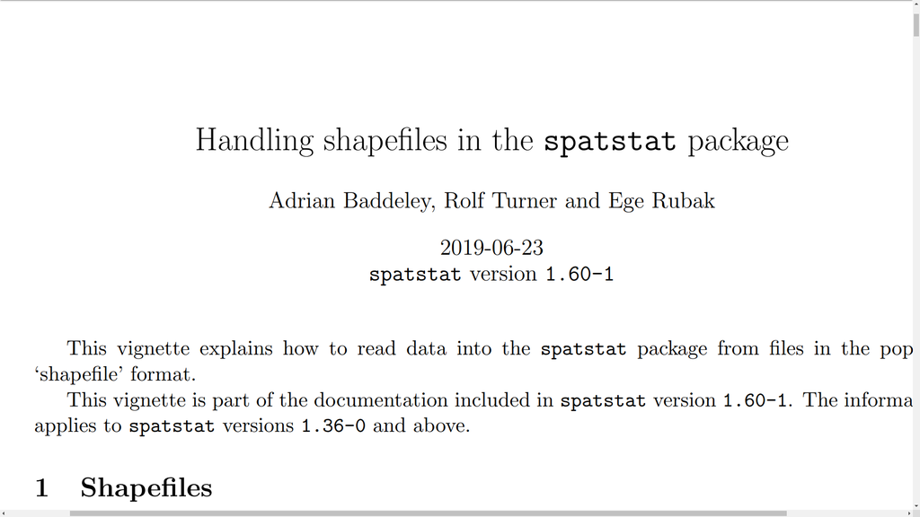

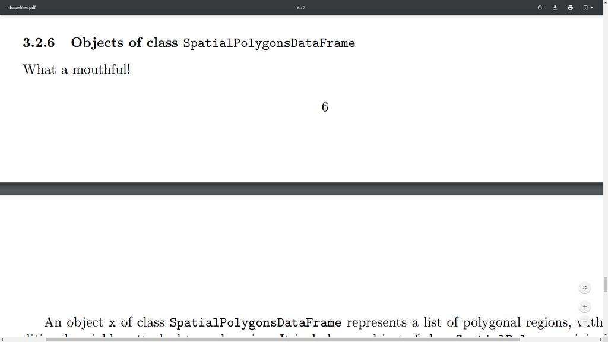

```r
suppressPackageStartupMessages(library(spatstat))
suppressPackageStartupMessages(library(maptools))
p = rbind(c(85, 10), c(87, 12), c(86, 8))
pts = SpatialPoints(rbind(p), proj4string = CRS("+proj=longlat"))
as.ppp(pts)
```

```
## Planar point pattern: 3 points
## window: rectangle = [85, 87] x [8, 12] units
```

## We need more intercomparisons

## We need more interoperability

[figure not shown]

## Big data

New(er) data sources

- are typically messy
- have large samples (really, really large): won't move; clouds
- often come with uncontrolled and/or unknown sampling processes
- To what extent are the methods we share on this conference ready for tackling this?
- The "normal" spatial statistics contribution contains a methodological innovation, quite often seemingly more as a purpose on itself, rather than motivated (as of: needed) by the application.
- In the light of problems we're facing (food security, disease transmissions, climate change), to what extent are these luxury problems? Is it reasonable to call for maximum likelyhood / Bayesian methods / … ?

## Other challenges / dangers

- Now that source code is dominantly open, the next lock-in is that of (open) standards and cloud platforms: what is our answer to that?
- If (spatial) data science is to be a new academic discipline, how much are we going to manage it?
- Suppose we have an academic tenure track position in data science: do we give it to the candidate with 30 CRAN package and 2 M downloads yearly, or to the candidate with an h factor of 15 and 1200 citations in total?